# How to NCM

Ramis Rafay

2026-05-06

# A guide to inferring immigration rates from abundance datasets

NOTE: The code is generally designed to work with abundance datasets packaged as Phyloseq objects.

## The quick way: read depth profiling and inference result visualization

The `depth_profile_ncm` function provides a convenient way to run all three NCM inference methods across a range of rarefied read depths. This is useful when you want to examine how sensitive the estimated immigration parameter is to sequencing depth.

Rather than manually rarefying the data, preparing the neutral model input, fitting each method, and repeating the process for multiple read depths, `depth_profile_ncm` performs this workflow automatically. For each specified read depth, the function applies the occupancy-based, variance-based, and Dirichlet multinomial log-likelihood methods, then returns a dataframe containing the fitted results.

In general, the function is useful for answering questions such as:

- Do the different inference methods converge toward similar estimates?
- Is there a read depth above which the estimates become relatively stable?

```
##         fit    upper     lower shared_species sample_size source_samples
## 1  916.5423 1144.034  733.0060           5288       90000             19
## 2 1240.4656 1607.502 1009.8724           5288       90000             19
## 3  627.2202       NA        NA           5288       90000             19
## 4  842.8893 1048.147  676.5841           5314       90000             19
## 5 1246.1857 1613.120 1015.2383           5314       90000             19
## 6  626.2723       NA        NA           5314       90000             19
##   local_samples    method
## 1            15 occupancy
## 2            15  variance
## 3            15     DM-LL
## 4            15 occupancy
## 5            15  variance
## 6            15     DM-LL
```

This can be visualized as below, showing how the occupancy, variance and DM-LL methods estimate change across read depths, and how well estimates agree with one another.

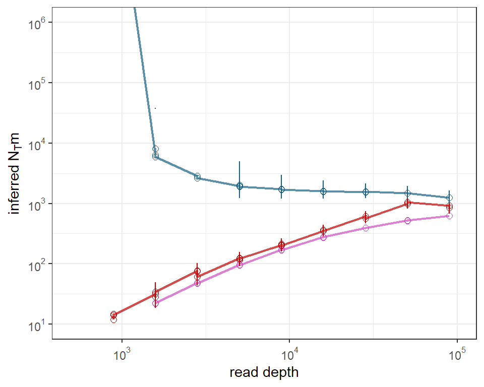

```r
ggplot(zheng_profile_results, aes(x = sample_size, y = fit)) +
  geom_line(aes(color = method), size = 0.75, alpha = 0.7) +
  geom_point(aes(color = method), size = 2, shape = 21) +
  geom_errorbar(aes(ymax = upper, ymin = lower, color = method), width = 0) +
  scale_color_manual(values = c("occupancy" = "#C00000", "variance" = "#156082", "DM-LL" = "#CE4ABE")) +
  scale_fill_manual(values = c("occupancy" = "#C0000050", "variance" = "#15608250", "DM-LL" = "#CE4ABE50")) +
  scale_x_continuous(trans = "log10",
                     breaks = breaks_log(base = 10),
                     labels = label_log(base = 10),
                     limits = c(5E2, 1E5)) +
  scale_y_continuous(trans = "log10",
                     breaks = breaks_log(base = 10, n = 6),
                     labels = label_log(base = 10),
                     limits = c(1E1, 1E20)) +
  coord_cartesian(ylim = c(1e1, 1e6)) +
  annotation_logticks(base = 10, outside = T, scaled = T, sides = "bl",
                      short = unit(0.05, "cm"), mid = unit(0.05, "cm"),
                      long = unit(0.1, "cm")) +
  labs(y = expression(inferred~N[T]*'m'),
       x = "read depth") +
  guides(fill = "none",
         color = "none") +
  theme(axis.title.x = element_blank()) +
  theme_bw()
```

## Manually fitting each method and inspecting plots of each fit

### Preparing abundance datasets for NCM fitting and inference

The `NCM_sample_prep` function takes in three inputs:

- The sample size used for rarefaction prior to conversion to relative abundances
- The abundance data corresponding to the source and local communities

What it returns is list consisting of:

- $Neutral_df: a table containing the means and variances of relative abundances, and their sample occupancies for the shared species between input source and local communities
- $summary: summary of the sample prep process
- $source_only: OTUs/ASVs only seen in the source community
- $local_only: OTUs/ASVs only seen in the local communty
- $all_data: data for all species

`Neutral_df` is required by all of the inference methods as a common input

```r
# Load necessary function files
source("Function_definitions.R")

# Load abundance dataset, here we will use the Zheng et. al dataset as an example
ps_zheng <- readRDS("ps_zheng2019.RDS") # this is a phyloseq object

# Set sample size and rarefy abundance table
samplesize <- 90000
seed <- 100 # Set seed number if reproducibility is required
ps_zheng_rare <- rarefy_even_depth(ps_zheng, sample.size = samplesize,
                                   rngseed = seed, trimOTUs = F, verbose = F)

# Delineate source community and local community samples
zheng_source <- subset_samples(ps_zheng_rare, sample_type == "IWW")
zheng_local <- subset_samples(ps_zheng_rare, sample_type == "AS")

# Prepare for NCM fitting and inference
zheng_neutraldata <- NCM_sample_prep(samplesize = samplesize, ps_local = zheng_local,
                                     ps_source = zheng_source, verbose = T, correction = T)
```

```
## [1] "taxa below detection limit (1/sample size) are not considered for analysis"
## [1] "# of shared taxa: 5287"
## [1] "number of shared taxa above detection limit: 3462"
## [1] "Abundance in shared community (%) 93.05"
## [1] "number of source-only taxa: 2042"
## [1] "number of local-only taxa: 1086"
```

```r
head(zheng_neutraldata$neutral_df)
```

```
##      column_index otu_name local_frequency local_abundance local_variance
## ASV1            1     ASV1       0.9333333    0.0011051852   6.202996e-06
## ASV2            2     ASV2       1.0000000    0.0009355556   3.951326e-06
## ASV3            3     ASV3       1.0000000    0.0004096296   8.393063e-08
## ASV4            4     ASV4       1.0000000    0.0154392593   1.069456e-04
## ASV5            5     ASV5       1.0000000    0.0158355556   2.002515e-05
## ASV6            6     ASV6       1.0000000    0.0178948148   1.744902e-04
##      source_frequency source_abundance source_variance
## ASV1                1      0.027291228    6.951222e-05
## ASV2                1      0.023512865    5.414243e-05
## ASV3                1      0.018215205    2.105568e-04
## ASV4                1      0.003269006    7.393835e-06
## ASV5                1      0.002642105    4.162889e-06
## ASV6                1      0.003330409    1.008492e-05
```

### Occupancy-based inference method

The occupancy-based method looks at how frequently each taxa are detected across samples, fitted against the NCM’s prediction.

For taxon $i$, the model assumes that the local relative abundance $x_i$ follows a beta distribution with shape parameters:

$$\alpha_i = N_T m p_i$$

and

$$\beta_i = N_T m(1-p_i)$$

where $p_i$ is the relative abundance of taxon $i$ in the source community, $m$ is the immigration probability, and $N_T$ is the effective community size.

The expected occurrence probability above the detection threshold $D$ is:

$$O_i
=
\int_D^1
\frac{
x_i^{\alpha_i - 1}
(1-x_i)^{\beta_i - 1}
}{
\mathrm{B}(\alpha_i,\beta_i)
}
\,dx_i$$

This integral gives the probability that taxon $i$ occurs above the detection limit in a local community.

```r
# Using the Zheng et. al dataset as an example
zheng_occ_fit <- fit_occ(samplesize = samplesize, neutral_data = zheng_neutraldata,
                         remove_ones = T)

zheng_occ_fit$fitting_results
```

```
##              fit               LL               UL              Rsq
##     8.977308e+02     7.176093e+02     1.121525e+03    -1.270811e+00
##      sample size  detection limit shared abundance
##     9.000000e+04     1.111111e-05     9.305000e+01
```

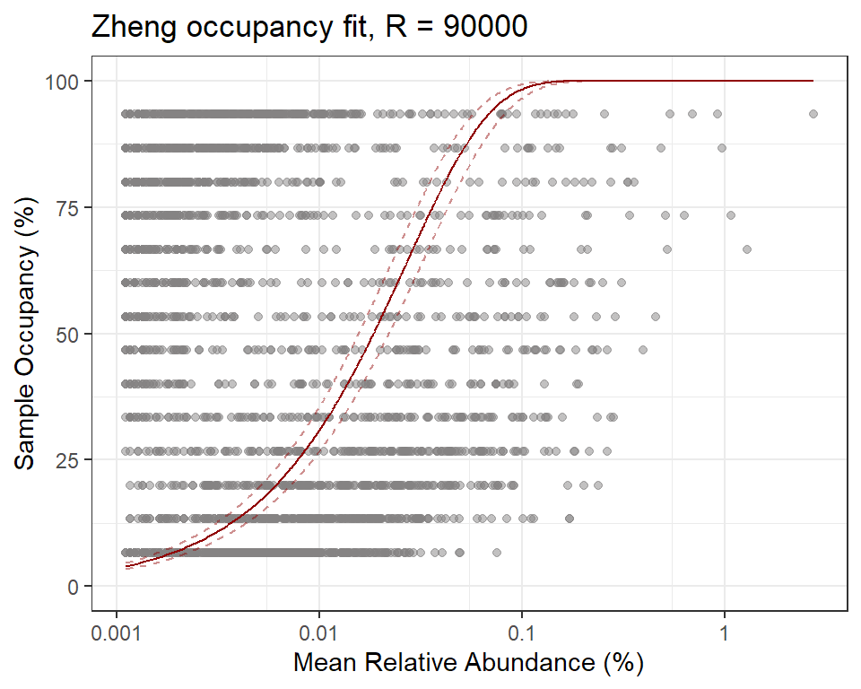

```r
# This can be visualized conveniently:
plot_occupancy <- function(ndf_w_preds, title){
  require(ggplot2)

  p <-  ggplot(ndf_w_preds) + aes(x = source_abundance * 100) +
    geom_point(aes(y = local_frequency * 100), colour = "#85838380") +
    geom_line(aes(y = predicted_freq * 100), colour = "#900000") +
    geom_line(aes(y = pred_LL * 100), color = "#90000070", linetype = "dashed") +
    geom_line(aes(y = pred_UL * 100), color = "#90000070", linetype = "dashed") +
    coord_trans(x = "log") + scale_x_continuous(breaks = c(1E-5, 1E-4, 1E-3, 1E-2, 1E-1, 1, 10),
                                                labels = c("0.00001", "0.0001", "0.001", "0.01", "0.1",
                                                           "1", "10")) +
    xlab("Mean Relative Abundance (%)") + ylab("Sample Occupancy (%)") + ylim(c(0, 100)) +
    theme_bw() + ggtitle(title)

  return(p)
}

plot_occupancy(zheng_occ_fit$ndf_w_preds, title = paste("Zheng occupancy fit, R =", samplesize))
```

### Variance-based inference method

The variance-based method estimates immigration by comparing the observed variance in taxon relative abundances across local communities with the variance expected under the Neutral Community Model.

For taxon $i$, the expected variance is:

$$\widehat{\mathrm{Var}}[X_i]
=
\frac{p_i(1-p_i)}{N_T m + 1}
+
\frac{p_i(1-p_i)}{R}$$

where $X_i$ is the relative abundance of taxon $i$ in the local community, $p_i$ is its relative abundance in the source community, $N_T$ is the effective community size, $m$ is the immigration probability, and $R$ is the rarefied sequencing depth.

The first term describes the variance expected from neutral community assembly. When $N_Tm$ is large, immigration strongly links local communities to the source community, reducing variation among local samples. When $N_Tm$ is small, local communities are more weakly connected to the source, and greater variation among local communities is expected.

The second term accounts for sampling variance caused by finite sequencing depth. This term is important because observed relative abundances are estimated from a finite number of reads rather than measured directly from the entire community.

```r
# Using the Zheng et. al dataset as an example
zheng_var_fit <- fit_var(samplesize = samplesize, neutral_data = zheng_neutraldata)
zheng_var_fit$fitting_results
```

```
##              fit               LL               UL              Rsq
##     1.276291e+03     1.037859e+03     1.656929e+03     1.663486e-02
##      sample size  detection limit shared abundance
##     9.000000e+04     1.111111e-05     9.305000e+01
```

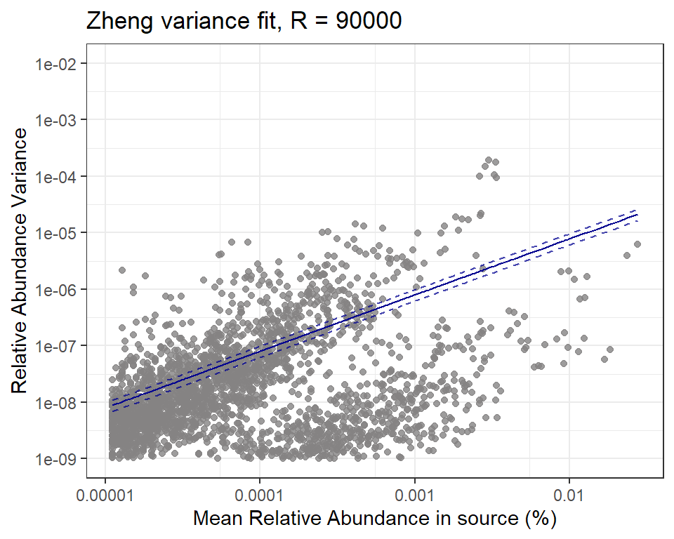

```r
# This can be visualized conveniently:
plot_variance <- function(ndf_w_preds, title){
  require(ggplot2)

  p <-  ggplot(ndf_w_preds) + aes(x = source_abundance) +
      geom_point(aes(y = local_variance), color = "#858383CC") +
      geom_line(aes(y = predicted_var), colour = "#000090") +
      geom_line(aes(y = predvar_LL), color = "#000090BB", linetype = "dashed") +
      geom_line(aes(y = predvar_UL), color = "#000090BB", linetype = "dashed") +
      scale_y_log10(limits = c(1E-9, 1E-2), n.breaks = 8) +
      coord_trans(x = "log") + scale_x_continuous(breaks = c(1E-5, 1E-4, 1E-3, 1E-2, 1E-1, 1, 10),
                                                  labels = c("0.00001", "0.0001", "0.001", "0.01", "0.1",
                                                             "1", "10")) +
      xlab("Mean Relative Abundance in source (%)") + ylab("Relative Abundance Variance") +
      theme_bw() + ggtitle(title)

  return(p)
}

plot_variance(zheng_var_fit$ndf_w_preds, title = paste("Zheng variance fit, R =", samplesize))
```

### Dirichlet multinomial log-likelihood method

The Dirichlet multinomial log-likelihood method estimates $N_Tm$ by maximizing the likelihood of the observed local community abundance data. Unlike the occupancy- and variance-based methods, which use taxon-level summary statistics, the DM-LL method uses the full local community abundance table.

For each local community sample $j$, the observed abundance vector $\mathbf{y}^{(j)}$ is treated as a multinomial sample drawn from an unobserved local relative abundance vector, $\hat{\mathbf{p}}$. This local abundance vector is assumed to vary around the source community composition according to a Dirichlet distribution parameterized by $N_Tm\mathbf{p}$:

$$P(\mathbf{y})
=
\prod_{j=1}^{J}
\int_{\hat{\mathbf{p}}}
\mathrm{Mult}
\left(
\mathbf{y}^{(j)} \mid R, \hat{\mathbf{p}}
\right)
\mathrm{Dir}
\left(
\hat{\mathbf{p}} \mid N_T m \mathbf{p}
\right)
\,d\hat{\mathbf{p}}$$

where $\mathbf{y}^{(j)}$ is the abundance vector for local sample $j$, $R$ is the rarefied sequencing depth, $\mathbf{p}$ is the source community relative abundance vector, and $N_Tm$ is the immigration parameter being estimated.

After integrating over $\hat{\mathbf{p}}$, the likelihood can be evaluated in closed form:

$$P(\mathbf{y})
=
\prod_{j=1}^{J}
\frac{
R\,\mathrm{B}(N_T m, R)
}{
\prod_{k: y_k^{(j)} > 0}
y_k^{(j)}
\,
\mathrm{B}
\left(
N_T m p_k,
y_k^{(j)}
\right)
}$$

The method then finds the value of $N_Tm$ that maximizes the log-likelihood. The log-likelihood is used instead of the raw likelihood for numerical stability.

Along with the `neutral_data` object returned by `NCM_sample_prep`, this method also requires the local community abundance table as input because it evaluates the likelihood of the observed abundance counts directly.

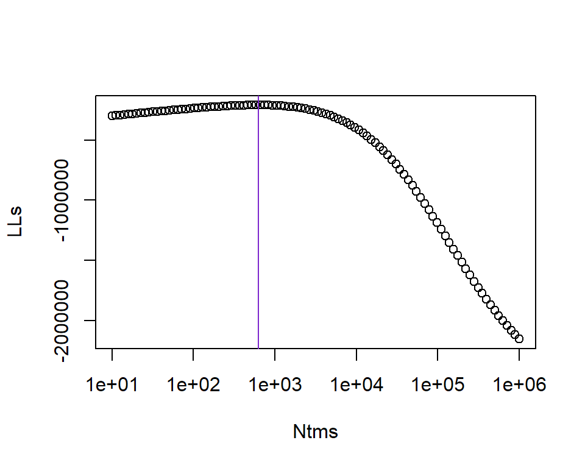

```r
zheng_DMLL_fit <- fit_DMLL(neutral_data = zheng_neutraldata, local = as.matrix(otu_table(zheng_local)),
                           samplesize = samplesize, plot = T, maxNTm = 1E6)
```